# Data Analytics-IST 707 HW01 - Association Rule Mining

**Submitted by : Jaishree Palaniswamy**

In this report we will be analysing the Employee Attrition dataset with all data mining steps.We will be performing Association Rule Mining to predict the attrition rate and the factors that causes the output. Then through the Shiny App, its been made interactive to users to find the prediction by changing the parameter values.

Shiny App link: https://jpalanis.shinyapps.io/HW01/

### **Data Loading:**

Load all the necessary packages

```r
library(ggplot2)
library(dplyr)
library(gridExtra)
library(arules)
library(tidyr)
library(tidyverse)
library(arulesViz)
```

### **Data Exploration:**

Then we can initialise the dataset and examine the stucture of the dataset with following code:

```r
data<- read.csv("employee_attrition.csv")
str(data)
```

```
## 'data.frame':    1176 obs. of  35 variables:
##  $ Age                     : int  30 52 42 55 35 51 42 23 38 27 ...
##  $ Attrition               : Factor w/ 2 levels "No","Yes": 1 1 1 1 1 1 1 1 1 2 ...
##  $ BusinessTravel          : Factor w/ 3 levels "Non-Travel","Travel_Frequently",..: 3 3 3 1 3 3 3 3 3 3 ...
##  $ DailyRate               : int  1358 1325 462 177 1029 1318 932 507 1153 1420 ...
##  $ Department              : Factor w/ 3 levels "Human Resources",..: 3 2 3 2 2 3 2 2 2 3 ...
##  $ DistanceFromHome        : int  16 11 14 8 16 26 1 20 6 2 ...
##  $ Education               : int  1 4 2 1 3 4 2 1 2 1 ...
##  $ EducationField          : Factor w/ 6 levels "Human Resources",..: 2 2 4 4 2 3 2 2 5 3 ...
##  $ EmployeeCount           : int  1 1 1 1 1 1 1 1 1 1 ...
##  $ EmployeeNumber          : int  1479 813 936 1278 1529 851 827 1533 1782 667 ...
##  $ EnvironmentSatisfaction : int  4 4 3 4 4 1 4 1 4 3 ...
##  $ Gender                  : Factor w/ 3 levels "","Female","Male": 3 2 2 3 2 2 2 3 2 3 ...
##  $ HourlyRate              : int  96 82 68 37 91 66 43 97 40 85 ...
##  $ JobInvolvement          : int  3 3 2 2 2 3 2 3 2 3 ...
```

[output cut: 21 more lines]

```r
summary(data)
```

```
##       Age        Attrition           BusinessTravel   DailyRate
##  Min.   :18.00   No :991   Non-Travel       :110    Min.   : 102.0
##  1st Qu.:30.00   Yes:185   Travel_Frequently:227    1st Qu.: 461.8
##  Median :36.00             Travel_Rarely    :839    Median : 796.0
##  Mean   :36.96                                      Mean   : 800.4
##  3rd Qu.:43.00                                      3rd Qu.:1162.0
##  Max.   :60.00                                      Max.   :1499.0
##
##                   Department  DistanceFromHome    Education
##  Human Resources       : 54   Min.   :  1.000   Min.   :1.000
##  Research & Development:764   1st Qu.:  2.000   1st Qu.:2.000
##  Sales                 :358   Median :  7.000   Median :3.000
##                               Mean   :  9.496   Mean   :2.895
##                               3rd Qu.: 14.000   3rd Qu.:4.000
##                               Max.   :224.000   Max.   :5.000
##                               NA's   :2
##           EducationField EmployeeCount EmployeeNumber   EnvironmentSatisfaction
##  Human Resources : 25    Min.   :1     Min.   :   1.0   Min.   :1.000
##  Life Sciences   :477    1st Qu.:1     1st Qu.: 499.8   1st Qu.:2.000
##  Marketing       :127    Median :1     Median :1032.5   Median :3.000
##  Medical         :381    Mean   :1     Mean   :1036.4   Mean   :2.705
##  Other           : 69    3rd Qu.:1     3rd Qu.:1574.5   3rd Qu.:4.000
##  Technical Degree: 97    Max.   :1     Max.   :2068.0   Max.   :4.000
##
##     Gender      HourlyRate     JobInvolvement     JobLevel
##        :  1   Min.   : 30.00   Min.   :1.000   Min.   :1.000
##  Female:482   1st Qu.: 48.00   1st Qu.:2.000   1st Qu.:1.000
##  Male  :693   Median : 66.00   Median :3.000   Median :2.000
##               Mean   : 65.82   Mean   :2.741   Mean   :2.069
##               3rd Qu.: 83.00   3rd Qu.:3.000   3rd Qu.:3.000
##               Max.   :100.00   Max.   :4.000   Max.   :5.000
##                                                NA's   :1
##                       JobRole    JobSatisfaction  MaritalStatus MonthlyIncome
##  Sales Executive          :263   Min.   :1.00    Divorced:266   Min.   : 1009
##  Research Scientist       :220   1st Qu.:2.00    Married :545   1st Qu.: 2954
##  Laboratory Technician    :209   Median :3.00    Single  :365   Median : 4950
##  Manufacturing Director   :122   Mean   :2.71                   Mean   : 6526
##  Healthcare Representative:108   3rd Qu.:4.00                   3rd Qu.: 8354
##  Manager                  : 79   Max.   :4.00                   Max.   :19973
##  (Other)                  :175
```

[output cut: 17 more lines]

```
##  Min.   :  0.0     Min.   :0.00          Min.   :1.000   Min.   : 0.000
##  1st Qu.:  6.0     1st Qu.:2.00          1st Qu.:2.000   1st Qu.: 3.000
##  Median : 10.0     Median :3.00          Median :3.000   Median : 5.000
##  Mean   : 11.4     Mean   :2.81          Mean   :2.747   Mean   : 6.918
##  3rd Qu.: 15.0     3rd Qu.:3.00          3rd Qu.:3.000   3rd Qu.: 9.000
##  Max.   :114.0     Max.   :6.00          Max.   :4.000   Max.   :40.000
##  NA's   :2
##  YearsInCurrentRole YearsSinceLastPromotion YearsWithCurrManager
##  Min.   : 0.000     Min.   : 0.000          Min.   :  0.000
##  1st Qu.: 2.000     1st Qu.: 0.000          1st Qu.:  2.000
##  Median : 3.000     Median : 1.000          Median :  3.000
##  Mean   : 4.151     Mean   : 2.125          Mean   :  4.242
##  3rd Qu.: 7.000     3rd Qu.: 2.000          3rd Qu.:  7.000
##  Max.   :18.000     Max.   :15.000          Max.   :219.000
##                     NA's   :1
```

Based on the above details, we could see that there are some blank values in Gender and OverTime columns.On more exploration of those attributes we can re-confirm it with the below code:

```r
levels(data$Gender)
```

```
## [1] ""       "Female" "Male"
```

```r
levels(data$OverTime)
```

```
## [1] ""    "No"  "Yes"
```

### **Data Preparation:**

##### **Missing Values:**

Lets look at the NA’s and missing values in the dataset

```r
sapply(data, function(x) sum(is.na(x)))
```

```
##                      Age                Attrition           BusinessTravel
##                        0                        0                        0
##                DailyRate               Department         DistanceFromHome
##                        0                        0                        2
##                Education           EducationField            EmployeeCount
##                        0                        0                        0
##           EmployeeNumber  EnvironmentSatisfaction                   Gender
##                        0                        0                        0
##               HourlyRate           JobInvolvement                 JobLevel
##                        0                        0                        1
##                  JobRole          JobSatisfaction            MaritalStatus
##                        0                        0                        0
##            MonthlyIncome              MonthlyRate       NumCompaniesWorked
##                        0                        0                        0
##                   Over18                 OverTime        PercentSalaryHike
##                        0                        0                        1
##        PerformanceRating RelationshipSatisfaction            StandardHours
##                        1                        1                        0
##         StockOptionLevel        TotalWorkingYears    TrainingTimesLastYear
##                        0                        2                        0
##          WorkLifeBalance           YearsAtCompany       YearsInCurrentRole
##                        0                        0                        0
##  YearsSinceLastPromotion     YearsWithCurrManager
##                        1                        0
```

We could see couple of NA’s available in few attributes.

Lets assign the NA value to the blank values in OverTime and Gender attribute to ignore the NA values in the dataset

```r
levels(data$OverTime)[levels(data$OverTime)==""] <- NA
levels(data$Gender)[levels(data$Gender)==""] <- NA
```

```r
summary(data)
```

```
##       Age        Attrition           BusinessTravel   DailyRate
##  Min.   :18.00   No :991   Non-Travel       :110    Min.   : 102.0
##  1st Qu.:30.00   Yes:185   Travel_Frequently:227    1st Qu.: 461.8
##  Median :36.00             Travel_Rarely    :839    Median : 796.0
##  Mean   :36.96                                      Mean   : 800.4
##  3rd Qu.:43.00                                      3rd Qu.:1162.0
##  Max.   :60.00                                      Max.   :1499.0
##
##                   Department  DistanceFromHome    Education
##  Human Resources       : 54   Min.   :  1.000   Min.   :1.000
##  Research & Development:764   1st Qu.:  2.000   1st Qu.:2.000
##  Sales                 :358   Median :  7.000   Median :3.000
##                               Mean   :  9.496   Mean   :2.895
##                               3rd Qu.: 14.000   3rd Qu.:4.000
##                               Max.   :224.000   Max.   :5.000
##                               NA's   :2
##           EducationField EmployeeCount EmployeeNumber   EnvironmentSatisfaction
##  Human Resources : 25    Min.   :1     Min.   :   1.0   Min.   :1.000
##  Life Sciences   :477    1st Qu.:1     1st Qu.: 499.8   1st Qu.:2.000
##  Marketing       :127    Median :1     Median :1032.5   Median :3.000
##  Medical         :381    Mean   :1     Mean   :1036.4   Mean   :2.705
##  Other           : 69    3rd Qu.:1     3rd Qu.:1574.5   3rd Qu.:4.000
##  Technical Degree: 97    Max.   :1     Max.   :2068.0   Max.   :4.000
##
##     Gender      HourlyRate     JobInvolvement     JobLevel
##  Female:482   Min.   : 30.00   Min.   :1.000   Min.   :1.000
##  Male  :693   1st Qu.: 48.00   1st Qu.:2.000   1st Qu.:1.000
##  NA's  :  1   Median : 66.00   Median :3.000   Median :2.000
##               Mean   : 65.82   Mean   :2.741   Mean   :2.069
##               3rd Qu.: 83.00   3rd Qu.:3.000   3rd Qu.:3.000
##               Max.   :100.00   Max.   :4.000   Max.   :5.000
##                                                NA's   :1
##                       JobRole    JobSatisfaction  MaritalStatus MonthlyIncome
##  Sales Executive          :263   Min.   :1.00    Divorced:266   Min.   : 1009
##  Research Scientist       :220   1st Qu.:2.00    Married :545   1st Qu.: 2954
##  Laboratory Technician    :209   Median :3.00    Single  :365   Median : 4950
##  Manufacturing Director   :122   Mean   :2.71                   Mean   : 6526
##  Healthcare Representative:108   3rd Qu.:4.00                   3rd Qu.: 8354
##  Manager                  : 79   Max.   :4.00                   Max.   :19973
##  (Other)                  :175
```

[output cut: 17 more lines]

```
##  Min.   :  0.0     Min.   :0.00          Min.   :1.000   Min.   : 0.000
##  1st Qu.:  6.0     1st Qu.:2.00          1st Qu.:2.000   1st Qu.: 3.000
##  Median : 10.0     Median :3.00          Median :3.000   Median : 5.000
##  Mean   : 11.4     Mean   :2.81          Mean   :2.747   Mean   : 6.918
##  3rd Qu.: 15.0     3rd Qu.:3.00          3rd Qu.:3.000   3rd Qu.: 9.000
##  Max.   :114.0     Max.   :6.00          Max.   :4.000   Max.   :40.000
##  NA's   :2
##  YearsInCurrentRole YearsSinceLastPromotion YearsWithCurrManager
##  Min.   : 0.000     Min.   : 0.000          Min.   :  0.000
##  1st Qu.: 2.000     1st Qu.: 0.000          1st Qu.:  2.000
##  Median : 3.000     Median : 1.000          Median :  3.000
##  Mean   : 4.151     Mean   : 2.125          Mean   :  4.242
##  3rd Qu.: 7.000     3rd Qu.: 2.000          3rd Qu.:  7.000
##  Max.   :18.000     Max.   :15.000          Max.   :219.000
##                     NA's   :1
```

Since we have very minimal number of NA’s in the dataset, we can omit them. After omitting, lets check whether the NA’s are removed in all the attributes

```r
new_data <- na.omit(data)
sum(is.na(new_data))
```

```
## [1] 0
```

##### **Duplicate Values:**

Now lets deal with the duplicate values in the dataset

```r
new_data<-new_data[!duplicated(new_data),]
```

Now our dataset is clean with no missing and duplicate values. Lets move on to the further analysis.

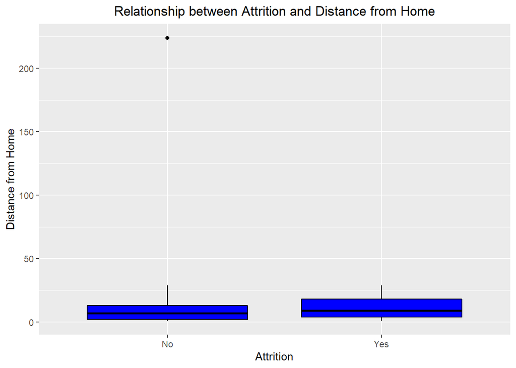

```r
ggplot(new_data, aes(x = Attrition, y = DistanceFromHome))+ geom_boxplot(color="black", fill="blue")+ xlab("Attrition") + ylab("Distance from Home") + ggtitle("Relationship between Attrition and Distance from Home") + theme(plot.title = element_text(hjust = 0.5))
```

##### **Analysis:**

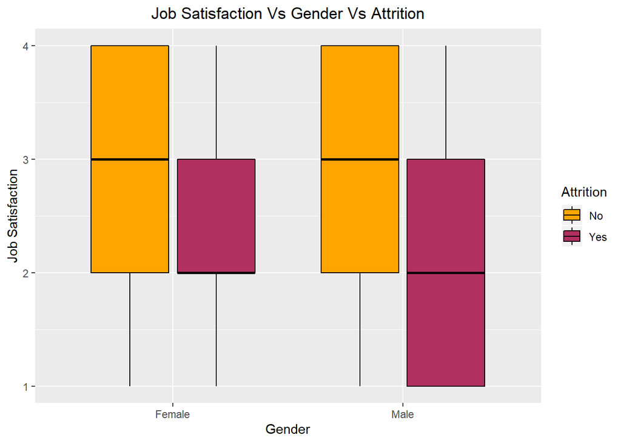

```r
ggplot(new_data,aes(x=Gender, y=JobSatisfaction, fill=Attrition)) + geom_boxplot(color="black") +xlab("Gender") +ylab("Job Satisfaction")+ ggtitle("Job Satisfaction Vs Gender Vs Attrition") +theme(plot.title = element_text(hjust = 0.5)) + scale_fill_manual(values=c("orange", "maroon"))
```

##### **Analysis:**

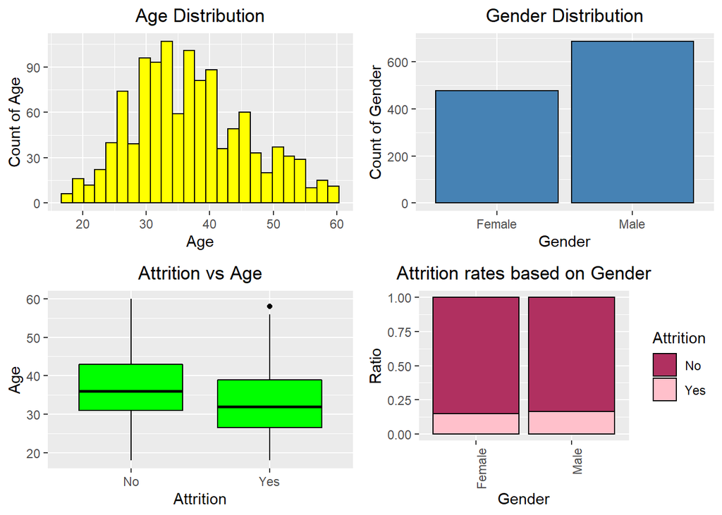

```r
plot1<-ggplot(new_data, aes(x=Age)) + geom_histogram(color="black", fill="yellow",bins = 25) + ggtitle("Age Distribution")+ theme(plot.title = element_text(hjust = 0.5)) + ylab("Count of Age") + xlab("Age")

plot2<-ggplot(new_data, aes(x=Gender)) + geom_bar(color="black", fill="steelblue") + ggtitle("Gender Distribution")+ theme(plot.title = element_text(hjust = 0.5)) + ylab("Count of Gender") + xlab("Gender")

plot3<-ggplot(new_data, aes(x = Attrition, y = Age))+ geom_boxplot(color = "black", fill="green") + xlab("Attrition") + ylab("Age") + ggtitle("Attrition vs Age") + theme(plot.title = element_text(hjust = 0.5))

plot4<-ggplot(new_data, aes(x = Gender, fill = Attrition)) + geom_bar(color="black",position = 'fill') + theme(axis.text.x = element_text(angle = 90, hjust = 1),plot.title = element_text(hjust = 0.5)) + xlab("Gender") + ylab("Ratio") + ggtitle("Attrition rates based on Gender")+scale_fill_manual(values=c("maroon", "pink"))

grid.arrange(plot1,plot2,plot3,plot4,nrow=2,ncol=2)
```

##### **Analysis:**

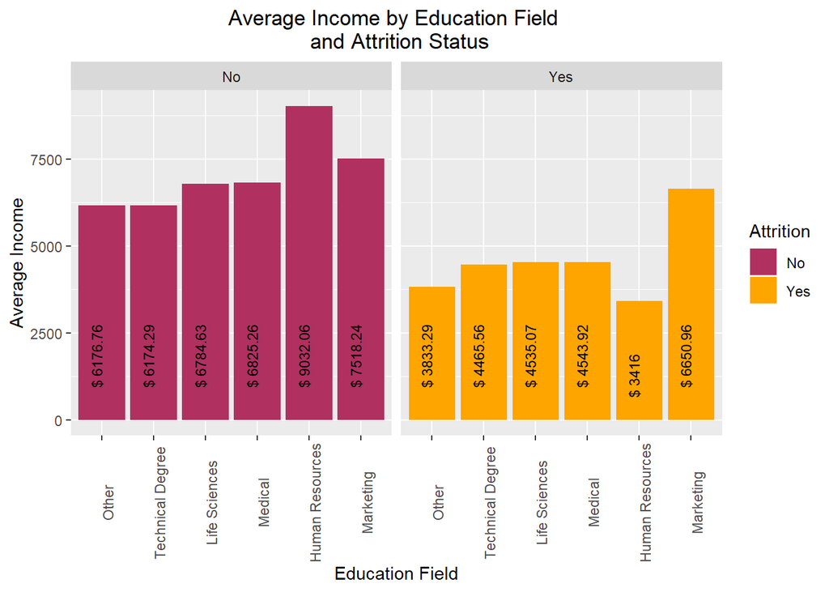

```r
options(repr.plot.width=8, repr.plot.height=5)

avg.income <- new_data %>% select(EducationField, MonthlyIncome, Attrition) %>% group_by(Attrition, EducationField) %>%
summarize(average_income=mean(MonthlyIncome)) %>%
ggplot(aes(x=reorder(EducationField, average_income), y=average_income, fill=Attrition)) + geom_bar(stat="identity") + facet_wrap(~Attrition) + theme(axis.text.x = element_text(angle = 90), plot.title=element_text(hjust=0.5)) +
scale_fill_manual(values=c("maroon", "orange")) +
labs(y="Average Income", x="Education Field", title="Average Income by Education Field \n and Attrition Status") +
geom_text(aes(x=EducationField, y=0.01, label= paste0("$ ", round(average_income,2))),
            hjust=-0.5, vjust=0, size=3, colour="black", angle=90)
avg.income
```

##### **Analysis:**

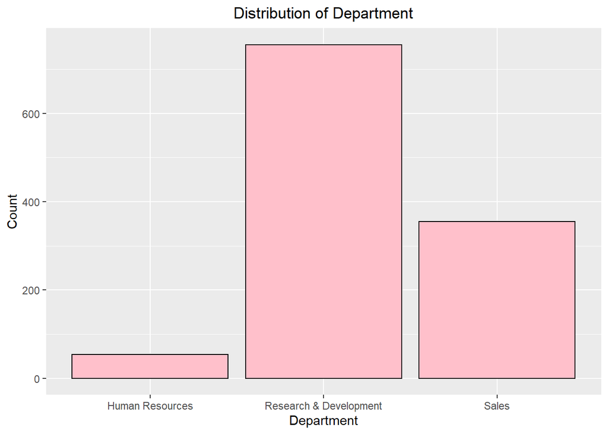

```r
ggplot(new_data, aes(x=Department)) + geom_bar(color="black", fill="pink",) + ggtitle("Distribution of Department")+ theme(plot.title = element_text(hjust = 0.5)) + ylab("Count") + xlab("Department")
```

##### **Analysis:**

From Distribution of Department plot, it is observed that majority of employees work in Research and Development.

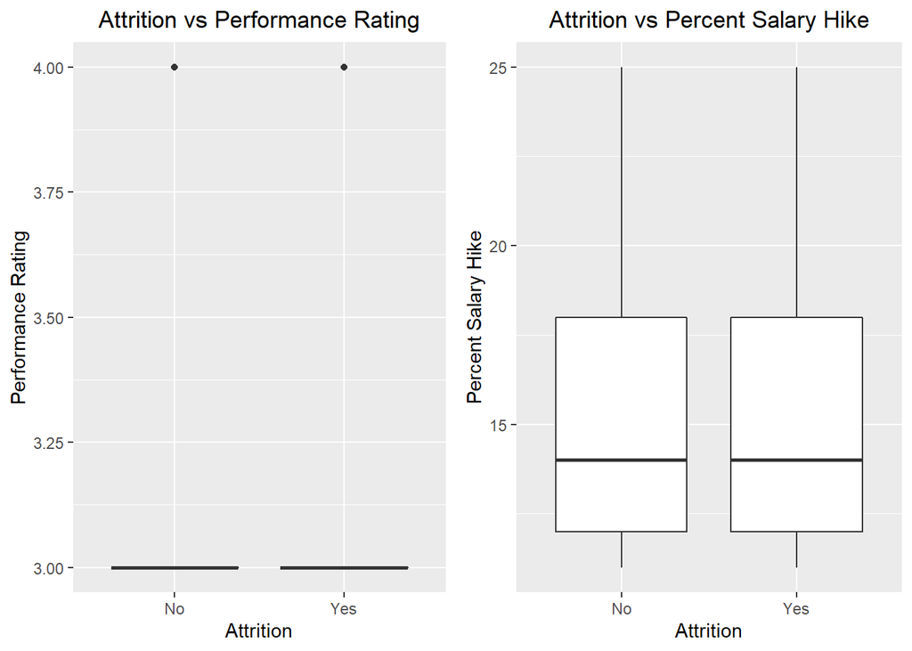

```r
plot5<- ggplot(new_data, aes(x = Attrition, y = PerformanceRating))+ geom_boxplot() + xlab("Attrition") + ylab("Performance Rating") + ggtitle("Attrition vs Performance Rating") + theme(plot.title = element_text(hjust = 0.5))
plot6<- ggplot(new_data, aes(x = Attrition, y = PercentSalaryHike))+ geom_boxplot() + xlab("Attrition") + ylab("Percent Salary Hike") + ggtitle("Attrition vs Percent Salary Hike") + theme(plot.title = element_text(hjust = 0.5))
grid.arrange(plot5,plot6,nrow=1)
```

##### **Analysis:**

From the above box plots, it is observed that the performance rating and percentage salary hike is same for employees with or without attrition.

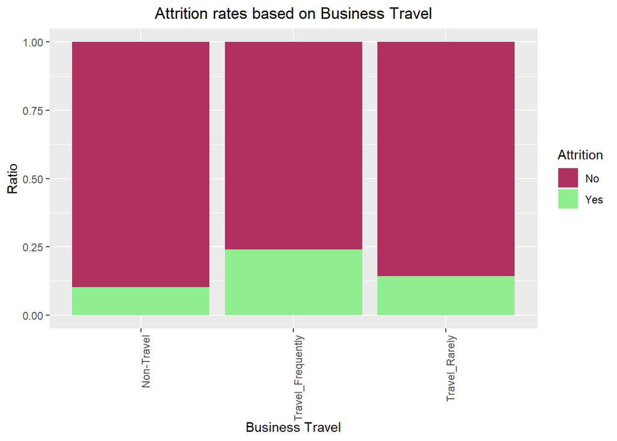

```r
ggplot(new_data, aes(x = BusinessTravel, fill = Attrition)) + geom_bar(position = 'fill') + theme(axis.text.x = element_text(angle = 90, hjust = 1),plot.title = element_text(hjust = 0.5)) + xlab("Business Travel") + ylab("Ratio") + ggtitle("Attrition rates based on Business Travel")+scale_fill_manual(values=c("maroon", "lightgreen"))
```

##### **Analysis:**

From the above barplot, we can observe that the propotion of employees who travel frequently are tend to leave the company more than the employees who do not travel.

### **Data Transformation:**

Now,lets convert all the integer values to numeric values to proceed with the discretization. Also, we can remove the attributes that are least important and the one that doesn’t contribute much for our analysis.So,‘Over18’,‘EmployeeCount’ and ‘StandardHours’ attributes are removed.

```r
for(i in c(1,4,6,7,9,10,11,13,14,15,17,19,20,21,24:35)) {new_data[i] <- lapply(new_data[i],as.numeric)}
new_data[,c(9,22,27)]<-NULL
```

Lets discretize the variables to ordinal categorical variables

```r
new_data$Age <- discretize(new_data$Age, method = "interval", breaks = 3, labels = c("Young", "Adult", "Old"), order = T)
new_data$DailyRate <- discretize(new_data$DailyRate, method = "interval", breaks = 5, labels = c("Lower","Low", "Medium", "High", "Higher"), order = T)
new_data$DistanceFromHome <- discretize(new_data$DistanceFromHome, method = "interval", breaks = 3, labels = c("Less", "Medium", "More"), order = T)
new_data$Education <- discretize(new_data$Education, method = "interval", breaks = 5, labels = c("High School","Associate", "Bachelors", "Masters", "PhD"), order = T)
new_data$EnvironmentSatisfaction <- discretize(new_data$EnvironmentSatisfaction, method = "interval", breaks = 4, labels = c("Dissatisfied", "Average", "Satisfied", "Extremely Satisfied"), order = T)
new_data$HourlyRate <- discretize(new_data$HourlyRate, method = "interval", breaks = 5, labels = c("Lower","Low", "Medium", "High", "Higher"), order = T)
new_data$JobInvolvement <- discretize(new_data$JobInvolvement, method = "interval", breaks = 4, labels = c("Low", "Medium", "High", "Very High"), order = T)
new_data$JobLevel <- discretize(new_data$JobLevel, method = "interval", breaks = 5, labels = c("Lower", "Low", "Medium", "High", "Very High"), order = T)
new_data$JobSatisfaction <- discretize(new_data$JobSatisfaction, method = "interval", breaks = 4, labels = c("Low", "Medium", "High", "Very High"), order = T)
new_data$MonthlyIncome <- discretize(new_data$MonthlyIncome, method = "frequency", breaks = 5, labels = c("Lower","Low", "Medium", "High", "Higher"), order = T)
new_data$MonthlyRate <- discretize(new_data$MonthlyRate, method = "interval", breaks = 5, labels = c("Lower","Low", "Medium", "High", "Higher"), order = T)
new_data$NumCompaniesWorked <- discretize(new_data$NumCompaniesWorked, method = "interval", breaks = 3, labels = c("Less", "Medium", "More"), order = T)
new_data$PercentSalaryHike <- discretize(new_data$PercentSalaryHike, method = "interval", breaks = 4, labels = c("Low", "Medium", "High", "Very High"), order = T)
new_data$PerformanceRating <- discretize(new_data$PerformanceRating, method = "interval", breaks = 3, labels = c("Low", "Good", "Excellent"), order = T)
new_data$RelationshipSatisfaction <- discretize(new_data$RelationshipSatisfaction, method = "interval", breaks = 4, labels = c("Low", "Medium", "High", "Very High"), order = T)
new_data$StockOptionLevel <- discretize(new_data$StockOptionLevel, method = "interval", breaks = 4, labels = c("Low", "Medium", "High", "Very High"), order = T)
new_data$TotalWorkingYears <- discretize(new_data$TotalWorkingYears, method = "frequency", breaks = 4, labels = c("Less", "Medium", "More", "Maximum"), order = T)
new_data$TrainingTimesLastYear <- discretize(new_data$TrainingTimesLastYear, method = "interval", breaks = 3, labels = c("Less", "Medium", "More"), order = T)
new_data$WorkLifeBalance <- discretize(new_data$WorkLifeBalance, method = "interval", breaks = 4, labels = c("Bad", "Good", "Better", "Best"), order = T)
new_data$YearsAtCompany <- discretize(new_data$YearsAtCompany, method = "frequency", breaks = 3, labels = c("Less", "Medium", "More"), order = T)
new_data$YearsInCurrentRole <- discretize(new_data$YearsInCurrentRole, method = "frequency", breaks = 3, labels = c("Less", "Medium", "More"), order = T)
new_data$YearsSinceLastPromotion <- discretize(new_data$YearsSinceLastPromotion, method = "interval", breaks = 4, labels = c("Less", "Medium", "More", "Maximum"))
new_data$YearsWithCurrManager <- discretize(new_data$YearsWithCurrManager, method = "frequency", breaks = 3, labels = c("Low", "Medium", "High"))
```

Lets have a look at the structure of final dataset:

```r
str(new_data)
```

```
## 'data.frame':    1165 obs. of  32 variables:
##  $ Age                     : Ord.factor w/ 3 levels "Young"<"Adult"<..: 1 3 2 3 2 3 2 1 2 2 ...
##   ..- attr(*, "discretized:breaks")= num  18 32 46 60
##   ..- attr(*, "discretized:method")= chr "interval"
##  $ Attrition               : Factor w/ 2 levels "No","Yes": 1 1 1 1 1 1 1 1 1 1 ...
##  $ BusinessTravel          : Factor w/ 3 levels "Non-Travel","Travel_Frequently",..: 3 3 3 1 3 3 3 3 3 2 ...
##  $ DailyRate               : Ord.factor w/ 5 levels "Lower"<"Low"<..: 5 5 2 1 4 5 3 2 4 5 ...
##   ..- attr(*, "discretized:breaks")= num  102 381 661 940 1220 ...
##   ..- attr(*, "discretized:method")= chr "interval"
##  $ Department              : Factor w/ 3 levels "Human Resources",..: 3 2 3 2 2 3 2 2 2 3 ...
##  $ DistanceFromHome        : Ord.factor w/ 3 levels "Less"<"Medium"<..: 1 1 1 1 1 1 1 1 1 1 ...
##   ..- attr(*, "discretized:breaks")= num  1 75.3 149.7 224
##   ..- attr(*, "discretized:method")= chr "interval"
##  $ Education               : Ord.factor w/ 5 levels "High School"<..: 1 4 2 1 3 4 2 1 2 4 ...
##   ..- attr(*, "discretized:breaks")= num  1 1.8 2.6 3.4 4.2 5
##   ..- attr(*, "discretized:method")= chr "interval"
##  $ EducationField          : Factor w/ 6 levels "Human Resources",..: 2 2 4 4 2 3 2 2 5 3 ...
##  $ EmployeeNumber          : num  1479 813 936 1278 1529 ...
##  $ EnvironmentSatisfaction : Ord.factor w/ 4 levels "Dissatisfied"<..: 4 4 3 4 4 1 4 1 4 4 ...
##   ..- attr(*, "discretized:breaks")= num  1 1.75 2.5 3.25 4
##   ..- attr(*, "discretized:method")= chr "interval"
##  $ Gender                  : Factor w/ 2 levels "Female","Male": 2 1 1 2 1 1 1 2 1 2 ...
##  $ HourlyRate              : Ord.factor w/ 5 levels "Lower"<"Low"<..: 5 4 3 1 5 3 1 5 1 4 ...
##   ..- attr(*, "discretized:breaks")= num  30 44 58 72 86 100
##   ..- attr(*, "discretized:method")= chr "interval"
##  $ JobInvolvement          : Ord.factor w/ 4 levels "Low"<"Medium"<..: 3 3 2 2 2 3 2 3 2 3 ...
##   ..- attr(*, "discretized:breaks")= num  1 1.75 2.5 3.25 4
##   ..- attr(*, "discretized:method")= chr "interval"
##  $ JobLevel                : Ord.factor w/ 5 levels "Lower"<"Low"<..: 2 2 2 4 3 4 2 2 1 2 ...
##   ..- attr(*, "discretized:breaks")= num  1 1.8 2.6 3.4 4.2 5
##   ..- attr(*, "discretized:method")= chr "interval"
##  $ JobRole                 : Factor w/ 9 levels "Healthcare Representative",..: 8 3 8 1 1 4 5 3 3 8 ...
##  $ JobSatisfaction         : Ord.factor w/ 4 levels "Low"<"Medium"<..: 3 3 3 2 2 3 4 3 3 4 ...
##   ..- attr(*, "discretized:breaks")= num  1 1.75 2.5 3.25 4
##   ..- attr(*, "discretized:method")= chr "interval"
##  $ MaritalStatus           : Factor w/ 3 levels "Divorced","Married",..: 2 2 3 1 3 2 2 3 2 3 ...
##  $ MonthlyIncome           : Ord.factor w/ 5 levels "Lower"<"Low"<..: 3 2 4 5 4 5 4 1 2 3 ...
##   ..- attr(*, "discretized:breaks")= num  1009 2720 4253 5766 9775 ...
##   ..- attr(*, "discretized:method")= chr "frequency"
##  $ MonthlyRate             : Ord.factor w/ 5 levels "Lower"<"Low"<..: 1 4 2 5 4 1 1 5 3 5 ...
```

[output cut: 26 more lines]

```
##   ..- attr(*, "discretized:method")= chr "interval"
##  $ YearsAtCompany          : Ord.factor w/ 3 levels "Less"<"Medium"<..: 1 2 2 3 3 3 2 2 2 1 ...
##   ..- attr(*, "discretized:breaks")= num  0 4 8 40
##   ..- attr(*, "discretized:method")= chr "frequency"
##  $ YearsInCurrentRole      : Ord.factor w/ 3 levels "Less"<"Medium"<..: 1 2 2 3 3 3 2 2 2 1 ...
##   ..- attr(*, "discretized:breaks")= num  0 2 6 18
##   ..- attr(*, "discretized:method")= chr "frequency"
##  $ YearsSinceLastPromotion : Factor w/ 4 levels "Less","Medium",..: 1 1 1 4 1 2 1 1 1 1 ...
##   ..- attr(*, "discretized:breaks")= num  0 3.75 7.5 11.25 15
##   ..- attr(*, "discretized:method")= chr "interval"
##  $ YearsWithCurrManager    : Factor w/ 3 levels "Low","Medium",..: 2 2 2 1 2 3 2 2 2 1 ...
##   ..- attr(*, "discretized:breaks")= num  0 2 6 219
##   ..- attr(*, "discretized:method")= chr "frequency"
##  - attr(*, "na.action")= 'omit' Named int  10 33 55 64 83 89 105 969 994 1013 ...
##   ..- attr(*, "names")= chr  "10" "33" "55" "64" ...
```

### **Association Rule Mining:**

Now lets run the dafault apriori function on the final dataset.

```r
emp_attrition_rules<- apriori(data = new_data)
```

Inspect the top 10 rules with high confidence

```r
inspect(head(sort(emp_attrition_rules, by='confidence'),10))
```

```
##      lhs                                 rhs                                   support confidence     lift count
## [1]  {JobInvolvement=Very High}       => {DistanceFromHome=Less}             0.1038627          1 1.000859   121
## [2]  {JobRole=Manufacturing Director} => {Department=Research & Development} 0.1047210          1 1.541005   122
## [3]  {JobRole=Manufacturing Director} => {DistanceFromHome=Less}             0.1047210          1 1.000859   122
## [4]  {EducationField=Marketing}       => {Department=Sales}                  0.1072961          1 3.281690   125
## [5]  {EducationField=Marketing}       => {DistanceFromHome=Less}             0.1072961          1 1.000859   125
## [6]  {StockOptionLevel=High}          => {DistanceFromHome=Less}             0.1090129          1 1.000859   127
## [7]  {Education=High School}          => {DistanceFromHome=Less}             0.1167382          1 1.000859   136
## [8]  {YearsSinceLastPromotion=Medium} => {DistanceFromHome=Less}             0.1459227          1 1.000859   170
## [9]  {JobLevel=Medium}                => {DistanceFromHome=Less}             0.1476395          1 1.000859   172
## [10] {Attrition=Yes}                  => {DistanceFromHome=Less}             0.1570815          1 1.000859   183
```

Plot the generated rules:

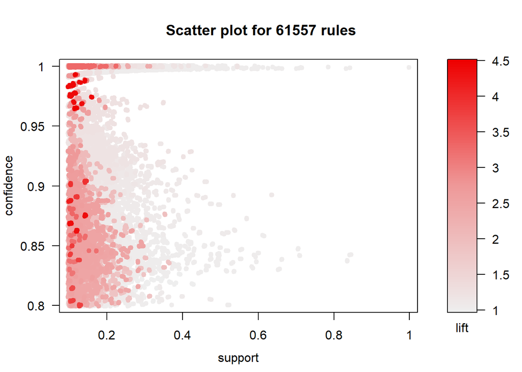

```r
plot(emp_attrition_rules)
```

##### **Analysis:**

From the above plot, it is observed that with the increase in support value, the lift and confidence becomes lower.

### Tuned Model:

Now let us set the confidence and support value to 0.5 and inspect the model

```r
emp_attrition_rules <- apriori(data=new_data, parameter=list (supp=0.5,conf =0.5, minlen= 2,maxtime=10, target = "rules"))
```

```
## Apriori
##
## Parameter specification:
##  confidence minval smax arem  aval originalSupport maxtime support minlen
##         0.5    0.1    1 none FALSE            TRUE      10     0.5      2
##  maxlen target   ext
##      10  rules FALSE
##
## Algorithmic control:
##  filter tree heap memopt load sort verbose
##     0.1 TRUE TRUE  FALSE TRUE    2    TRUE
##
## Absolute minimum support count: 582
##
## set item appearances ...[0 item(s)] done [0.00s].
## set transactions ...[121 item(s), 1165 transaction(s)] done [0.00s].
## sorting and recoding items ... [14 item(s)] done [0.00s].
## creating transaction tree ... done [0.00s].
## checking subsets of size 1 2 3 4 done [0.00s].
## writing ... [147 rule(s)] done [0.00s].
## creating S4 object  ... done [0.00s].
```

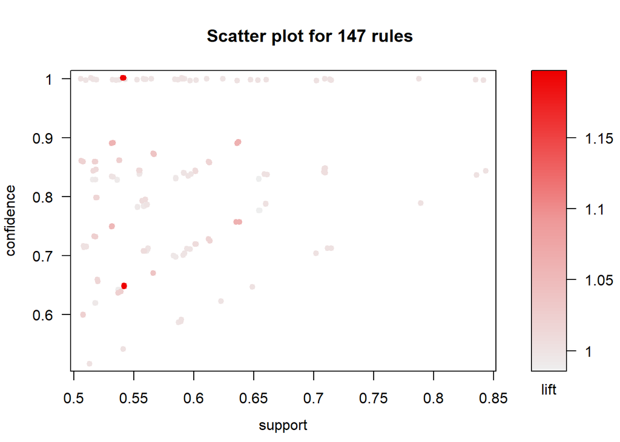

```r
plot(emp_attrition_rules)
```

##### **Analysis:**

```r
inspect(head(sort(emp_attrition_rules, by='confidence'),10))
```

```
##      lhs                        rhs                       support confidence      lift count
## [1]  {Age=Adult}             => {DistanceFromHome=Less} 0.5141631  1.0000000 1.0008591   599
## [2]  {PercentSalaryHike=Low} => {PerformanceRating=Low} 0.5416309  1.0000000 1.1948718   631
## [3]  {PercentSalaryHike=Low} => {DistanceFromHome=Less} 0.5416309  1.0000000 1.0008591   631
## [4]  {JobInvolvement=High}   => {DistanceFromHome=Less} 0.5888412  1.0000000 1.0008591   686
## [5]  {Gender=Male}           => {DistanceFromHome=Less} 0.5896996  1.0000000 1.0008591   687
## [6]  {PercentSalaryHike=Low,
##       PerformanceRating=Low} => {DistanceFromHome=Less} 0.5416309  1.0000000 1.0008591   631
## [7]  {DistanceFromHome=Less,
##       PercentSalaryHike=Low} => {PerformanceRating=Low} 0.5416309  1.0000000 1.1948718   631
## [8]  {Attrition=No,
##       JobInvolvement=High}   => {DistanceFromHome=Less} 0.5064378  1.0000000 1.0008591   590
## [9]  {Attrition=No}          => {DistanceFromHome=Less} 0.8420601  0.9989817 0.9998399   981
## [10] {PerformanceRating=Low} => {DistanceFromHome=Less} 0.8360515  0.9989744 0.9998326   974
```

### **Attrition Prediction:**

Now let us predict the association of attrition with other attributes.We can set the target as “rules” and rhs as “Attrition=Yes” and “Attrition=No”

```r
emp_attrition_rules <- apriori(data=new_data, parameter=list (supp=0.5,conf =0.5, minlen= 2, maxtime=10, target = "rules"), appearance = list (rhs=c("Attrition=Yes", "Attrition=No")))
```

```
## Apriori
##
## Parameter specification:
##  confidence minval smax arem  aval originalSupport maxtime support minlen
##         0.5    0.1    1 none FALSE            TRUE      10     0.5      2
##  maxlen target   ext
##      10  rules FALSE
##
## Algorithmic control:
##  filter tree heap memopt load sort verbose
##     0.1 TRUE TRUE  FALSE TRUE    2    TRUE
##
## Absolute minimum support count: 582
##
## set item appearances ...[2 item(s)] done [0.00s].
## set transactions ...[121 item(s), 1165 transaction(s)] done [0.00s].
## sorting and recoding items ... [14 item(s)] done [0.00s].
## creating transaction tree ... done [0.00s].
## checking subsets of size 1 2 3 4 done [0.00s].
## writing ... [23 rule(s)] done [0.00s].
## creating S4 object  ... done [0.00s].
```

```r
inspect(head(sort(emp_attrition_rules, by='confidence'),10))
```

```
##      lhs                                    rhs              support confidence     lift count
## [1]  {OverTime=No}                       => {Attrition=No} 0.6369099  0.8929001 1.059296   742
## [2]  {DistanceFromHome=Less,
##       OverTime=No}                       => {Attrition=No} 0.6360515  0.8927711 1.059143   741
## [3]  {OverTime=No,
##       PerformanceRating=Low}             => {Attrition=No} 0.5321888  0.8920863 1.058331   620
## [4]  {DistanceFromHome=Less,
##       OverTime=No,
##       PerformanceRating=Low}             => {Attrition=No} 0.5313305  0.8919308 1.058146   619
## [5]  {Department=Research & Development} => {Attrition=No} 0.5665236  0.8730159 1.035706   660
## [6]  {Department=Research & Development,
##       DistanceFromHome=Less}             => {Attrition=No} 0.5656652  0.8728477 1.035507   659
## [7]  {WorkLifeBalance=Better}            => {Attrition=No} 0.5381974  0.8624484 1.023169   627
## [8]  {DistanceFromHome=Less,
##       WorkLifeBalance=Better}            => {Attrition=No} 0.5373391  0.8622590 1.022945   626
## [9]  {BusinessTravel=Travel_Rarely,
##       PerformanceRating=Low}             => {Attrition=No} 0.5184549  0.8603989 1.020738   604
## [10] {BusinessTravel=Travel_Rarely,
##       DistanceFromHome=Less,
##       PerformanceRating=Low}             => {Attrition=No} 0.5175966  0.8601997 1.020502   603
```

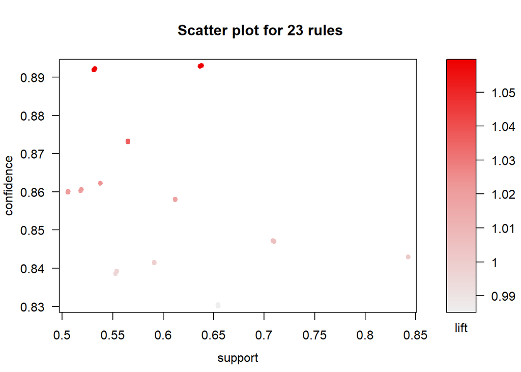

```r
plot(emp_attrition_rules)
```

#### **Output:**

On fine tuning, we got around 23 rules with highest rule with support of 0.6369, confidence of 0.8929 and lift of 1.0592.The employees are predicted to stay in the company when they doesn’t need to work overtime and with the less distance from home. Also based on the factor that they travel rarely.Even though when the company provides a low performance rating, the employees are comfortable with it considering other factors like less distance from home, no overtime and rare business travels.